# Midlife Crisis - Data appendix

Ingo Rohlfing

2021-07-02 13:41:44

## Individual-level analysis data set (`individual_level.rds`)

The individual-level data set contains observations representing 10355 individuals from 7 countries.

The distribution of observations across countries is as follows:

| Country name | n |
| --- | --- |
| China | 2837 |
| India | 1887 |
| Indonesia | 910 |
| Jordan | 931 |
| Pakistan | 1629 |
| Russian Federation | 916 |
| United States | 1245 |

The individual-level data set contains two individual-level variables:

- `satis`
- `age`

Definitions, summary statistics and illustrations of the distributions of those two variables are shown below.

Variable name: `satis`  
Source: Pew data set  
Values: Integers from 0 through 10 Coding: Respondent’s assessment of her/his overall satisfaction with life on a scale of 0 (least satisfied) to 10 (most satisfied)

Distribution of frequencies.

Table 1: Frequency of satisfaction scores

| Satisfaction score | Frequency |
| --- | --- |
| 0 | 248 |
| 1 | 269 |
| 2 | 417 |
| 3 | 776 |
| 4 | 991 |
| 5 | 2947 |
| 6 | 1587 |
| 7 | 1272 |
| 8 | 1105 |
| 9 | 334 |
| 10 | 409 |

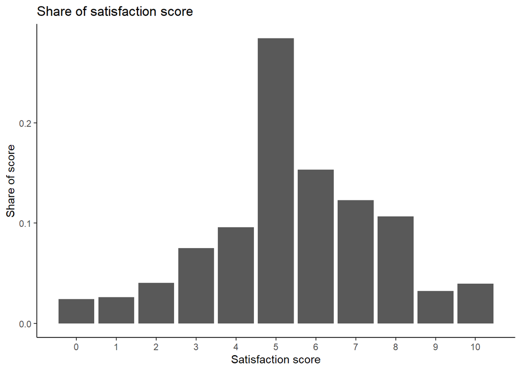

Variable name: `age`  
Source: Pew data set  
Values: Positive integers  
Coding: Respondent’s age in years at last birthday

```
##    Min. 1st Qu.  Median    Mean 3rd Qu.    Max.
##   21.00   29.00   39.00   39.63   49.00   70.00
```

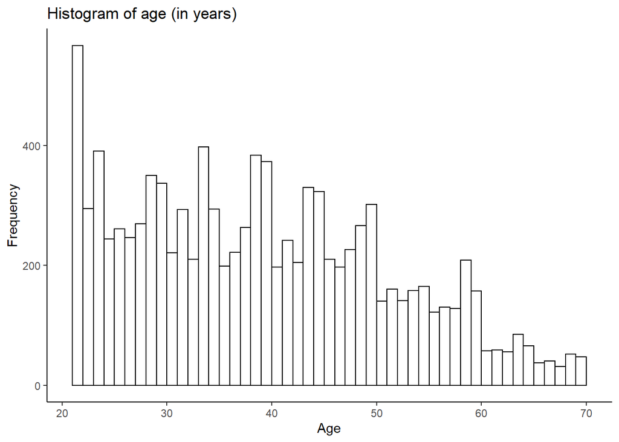

## Country-level analysis data set (`country_analysis.rds`)

The country-level data set contains one observation for each of the 7 countries included in the individual-level data set.

The country-level data set contains three variables:

- `cm_satis`
- `inc`
- `exp`

Definitions, summary statistics and illustrations of the distributions of those three variables are shown below.

Variable name: `cm_satis`  
Source: Pew data set  
Values: Real numbers from 0 through 10  
Definition: Mean value of `satis` for all respondents from the country

```
##    Min. 1st Qu.  Median    Mean 3rd Qu.    Max.
##   4.741   5.130   5.344   5.514   5.617   7.019
```

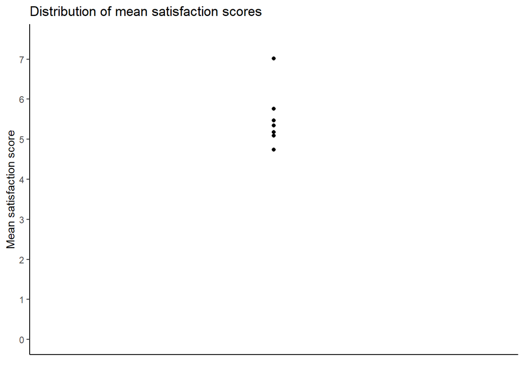

Variable name: `exp`  
Source: WDI  
Values: Positive real numbers  
Definition: General government consumption expenditure for 2002, as a percentage of GDP

```
##    Min. 1st Qu.  Median    Mean 3rd Qu.    Max.
##   7.257  10.307  15.040  14.164  16.772  22.696
```

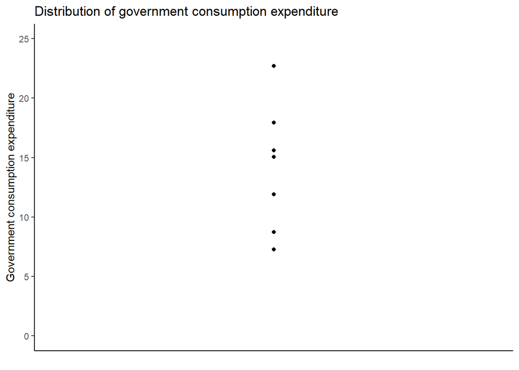

Variable name: `inc`  
Source: WDI  
Values: Positive real numbers  
Definition: Income per capita for 2002, current US dollars

```
##    Min. 1st Qu.  Median    Mean 3rd Qu.    Max.
##   483.0   698.3  1135.5  6495.3  2138.4 38175.4
```

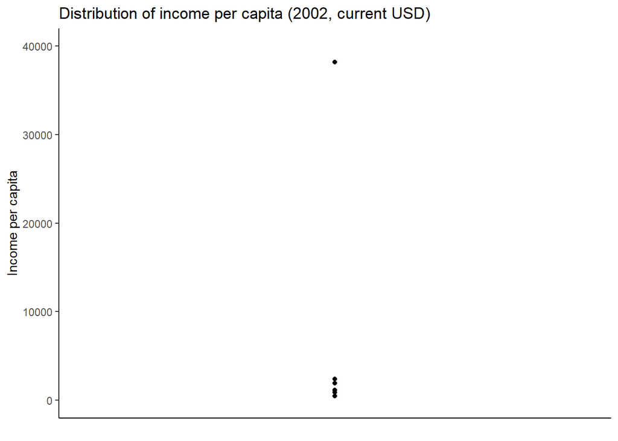